# analysis

```r
library(dplyr)
library(ggplot2)
library(tidyr)
```

# Loading the data

```r
human_df <- read.csv(file = "/Users/anastasialinchik/Desktop/Thesis/DATA/Human-separateProjects.csv", header = T)
human_ptms_expanded_hl <- read.csv(file = "/Users/anastasialinchik/Desktop/Thesis/DATA/generated/human_ptms_expanded_hl.tsv", header = T, sep = '\t')
human_ptms_expanded_length <- read.csv(file = "/Users/anastasialinchik/Desktop/Thesis/DATA/generated/human_ptms_expanded_length.tsv", header = T, sep = '\t')
human_ptms_expanded_hl_lengths <- read.csv(file = "/Users/anastasialinchik/Desktop/Thesis/DATA/generated/human_ptms_expanded_hl_lengths.tsv", header = T, sep = '\t')
```

**Important**

- I think I am doing something wrong here because the p values are not really showing what I am expecting to see based on the graphs.
- I am also not sure whether I should be working with subsets of data at this point because the dataframe with only the top 5 modifications has 1.5 million entries.

- We want to investigate the effect of the type of PTM on the half-life of the proteins.

#### Assumptions

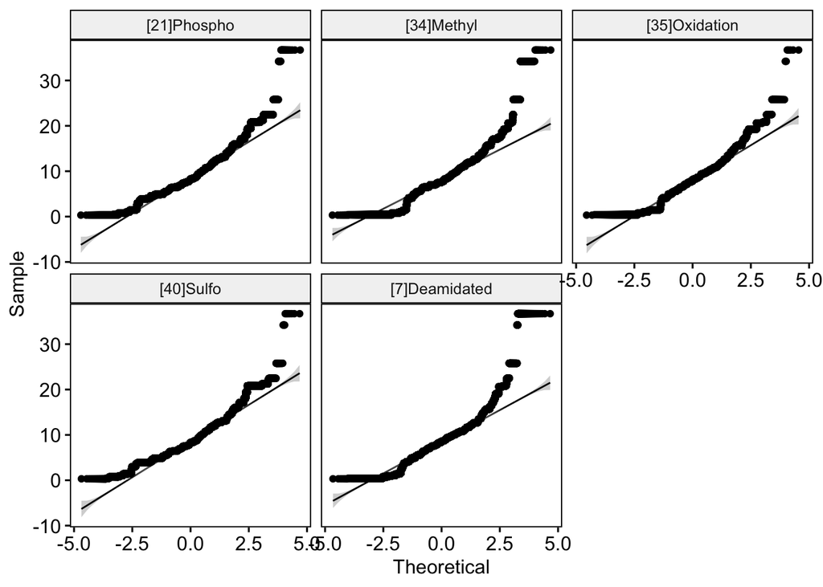

```r
library(ggpubr)
library(rstatix)
human_ptms_expanded_hl_top5 <- human_ptms_expanded_hl %>% filter(ptm_name %in% c('[35]Oxidation', '[34]Methyl', '[40]Sulfo', '[21]Phospho', '[7]Deamidated'))

# normality assumption

# Build the linear model
model  <- lm(mean_hl_hours ~ ptm_name, data = human_ptms_expanded_hl_top5)
# Create a QQ plot of residuals
#ggqqplot(residuals(model))
ggqqplot(human_ptms_expanded_hl_top5, "mean_hl_hours", facet.by = "ptm_name")
```

```r
# homogeneity of variances
human_ptms_expanded_hl_top5 %>% levene_test(mean_hl_hours ~ ptm_name)
```

```
# A tibble: 1 × 4
    df1     df2 statistic     p
  <int>   <int>     <dbl> <dbl>
1     4 1616137      418.     0
```

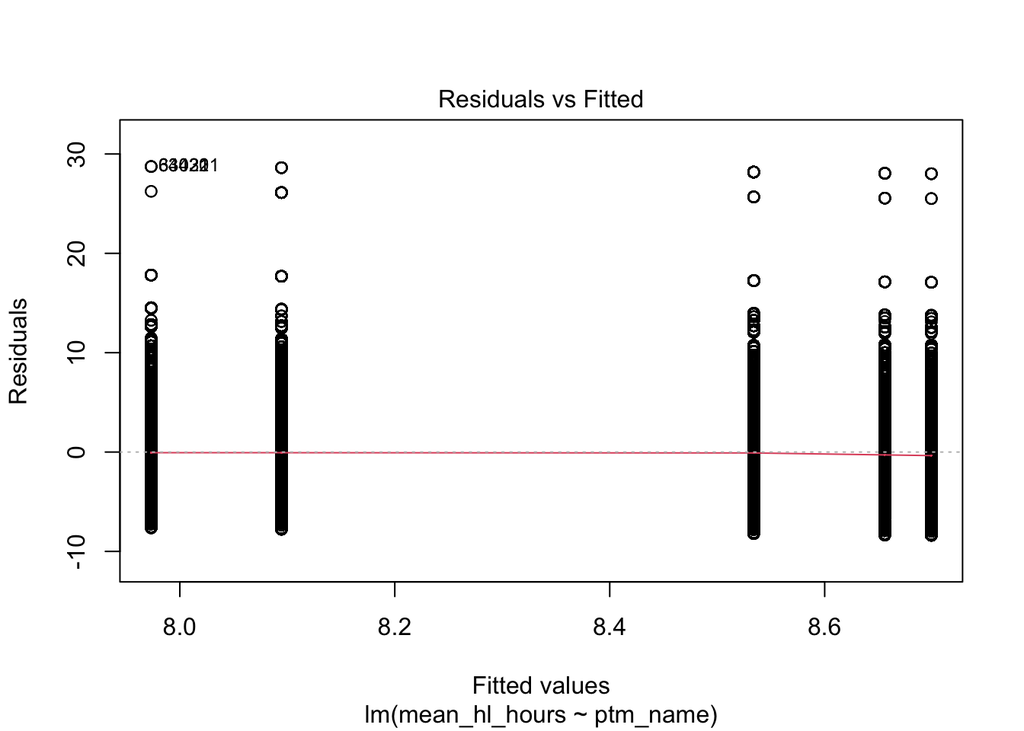

```r
plot(model, 1)
```

#### Test

Parametric test, assume that the assumptions are met.

```r
table_aov <- aov(human_ptms_expanded_hl_top5$mean_hl_hours ~ human_ptms_expanded_hl_top5$ptm_name, data = human_ptms_expanded_hl_top5)
summary(table_aov)
```

```
                                          Df   Sum Sq Mean Sq F value Pr(>F)
human_ptms_expanded_hl_top5$ptm_name       4   128606   32151    2950 <2e-16
Residuals                            1616137 17610927      11

human_ptms_expanded_hl_top5$ptm_name ***
Residuals
---
Signif. codes:  0 '***' 0.001 '**' 0.01 '*' 0.05 '.' 0.1 ' ' 1
```

```r
values <- TukeyHSD(table_aov)
```

### Krustal test

Non-parametric. (Normality assumption is not met)

**Important**

It appears that the normality assumption is not met, so I shouldn’t use the parametric test, however, there is definitely something wrong here because I am expecting a high p value, not a low one. Also a p value of 0 seems strange?

```r
library(rstatix)
res.kruskal <- human_ptms_expanded_hl_top5 %>% kruskal_test(mean_hl_hours ~ ptm_name)
res.kruskal
```

```
# A tibble: 1 × 6
  .y.                 n statistic    df     p method
* <chr>           <int>     <dbl> <int> <dbl> <chr>
1 mean_hl_hours 1616142     6927.     4     0 Kruskal-Wallis
```

```r
pwc2 <- human_ptms_expanded_hl_top5 %>%
  wilcox_test(mean_hl_hours ~ ptm_name, p.adjust.method = "bonferroni")
pwc2
```

```
# A tibble: 10 × 9
   .y.      group1 group2     n1     n2 statistic        p    p.adj p.adj.signif
 * <chr>    <chr>  <chr>   <int>  <int>     <dbl>    <dbl>    <dbl> <chr>
 1 mean_hl… [21]P… [34]M… 398881 357074   7.56e10 0        0        ****
 2 mean_hl… [21]P… [35]O… 398881 187052   4.05e10 0        0        ****
 3 mean_hl… [21]P… [40]S… 398881 354859   7.03e10 1.51e- 6 1.51e- 5 ****
 4 mean_hl… [21]P… [7]De… 398881 318276   6.26e10 3.30e-25 3.30e-24 ****
 5 mean_hl… [34]M… [35]O… 357074 187052   3.39e10 6.97e-17 6.97e-16 ****
 6 mean_hl… [34]M… [40]S… 357074 354859   5.90e10 0        0        ****
 7 mean_hl… [34]M… [7]De… 357074 318276   5.18e10 0        0        ****
 8 mean_hl… [35]O… [40]S… 187052 354859   3.02e10 0        0        ****
 9 mean_hl… [35]O… [7]De… 187052 318276   2.68e10 0        0        ****
10 mean_hl… [40]S… [7]De… 354859 318276   5.60e10 8.2 e- 8 8.2 e- 7 ****
```

## Protein lengths

### Testing statistical significance

Larger proteins should be modified more than shorter proteins.

**Important**

How do I know at what point a protein is ‘long’ or ‘short’, if I want to check the differences in the number of PTMs between the two. It seems to be a very arbitrary threshold?

```r
library(stats)

human_ptms_expanded_length %>%
  group_by(LeadProt) %>%
  mutate(counts = n()) %>%
  select(LeadProt, counts, Length) %>% distinct()
```

```
# A tibble: 18,916 × 3
# Groups:   LeadProt [18,916]
   LeadProt counts Length
   <chr>     <int>  <int>
 1 P31946     4030    246
 2 P61981     6925    247
 3 P62258     7803    255
 4 Q04917     2550    246
 5 P27348     6601    245
 6 P63104     9258    245
 7 P01009    21397    418
 8 P01023    16855   1474
 9 P01011     7963    423
10 P17174     1154    413
# ℹ 18,906 more rows
```

```r
human_ptms_expanded_length_aov <- human_ptms_expanded_length %>% mutate(length_group = ifelse(Length < 2500, 'short', 'long'))

table_aov <- aov(human_ptms_expanded_length_aov$Length ~ human_ptms_expanded_length_aov$length_group, data = human_ptms_expanded_length_aov)
summary(table_aov)
```

```
                                                 Df    Sum Sq   Mean Sq F value
human_ptms_expanded_length_aov$length_group       1 5.927e+12 5.927e+12 7061214
Residuals                                   9917833 8.325e+12 8.394e+05
                                            Pr(>F)
human_ptms_expanded_length_aov$length_group <2e-16 ***
Residuals
---
Signif. codes:  0 '***' 0.001 '**' 0.01 '*' 0.05 '.' 0.1 ' ' 1
```